# Introduction to bbreg

Wagner Barreto-Souza, Vinicius D. Mayrink, Alexandre B. Simas

```r
library(bbreg)
```

# Brief introduction

The *bbreg* package deals with regression models with response variables being continuous and bounded. It currently provides implementation of two regression models: beta regression https://www.tandfonline.com/doi/abs/10.1080/0266476042000214501 and bessel regression https://doi.org/10.1111/anzs.12354 and https://arxiv.org/abs/2003.05157. For both of these models, the estimation is done with the EM-algorithm. The EM-algorithm approach for beta regression was developed in https://www.tandfonline.com/doi/abs/10.1080/00949655.2017.1350679.

# Choosing between bessel regression and beta regression

There are several manners to choose between bessel and beta regression, most of them using diagnostic analysis. One approach we would like to call attention is the **discrimination test** developed in the bessel regression paper https://doi.org/10.1111/anzs.12354 and https://arxiv.org/abs/2003.05157. This discrimination test has a very nice performance on selecting the “correct” distribution (in the sense that it performs well with synthetic data) and is implemented in the *bbreg* package.

Another approach to select between bessel and beta regression models is to use quantile-quantile plots with simulated envelopes. The *bbreg* package also has a function to build such plots.

We will show below how to use the discrimination test and how to construct the quantile-quantile plot with simulated envelopes.

# Using the bbreg package

From version 2.0.0 onward, the usage of the *bbreg* package is standard in the sense that it uses *formula* to handle data frames and that it has several standard S3 methods implemented, such as *summary*, *plot*, *fitted*, *predict*, etc.

If the regression model is not specified (via the *model* parameter), the discrimination test is used to select the regression model to be used.

## Fitting *bbreg* (bessel or beta regression) models

Let us fit a model:

```r
fit <- bbreg(agreement ~ priming + eliciting, data = WT)
```

Let us now see its output (notice that it provides a nice print when the fitted object is called):

```r
fit
```

```
#>
#> Bessel regression via EM - Model selected via Discrimination test (DBB)
#>
#> Call:
#> bbreg(agreement ~ priming + eliciting | 1)
#>
#> Coefficients modeling the mean (with logit link):
#> (intercept)     priming   eliciting
#>  -1.1537851  -0.2548633   0.3392742
#> Coefficients modeling the precision (with identity link):
#> (intercept)
#>    4.924825
```

It is also noteworthy that the bessel regression model was chosen based on the discrimination criteria. If we want to fit a beta regression model (with estimates obtained from the EM algorithm, which are more robust than the usual maximum likelihood estimates due to the flatness of the likelihood function with respect to the precision parameter), we pass the argument *model = “beta”*:

```r
fit_beta <- bbreg(agreement ~ priming + eliciting, data = WT, model = "beta")
fit_beta
```

```
#>
#> Beta regression via EM - Ignoring the Discrimination test (DBB)
#>
#> Call:
#> bbreg(agreement ~ priming + eliciting | 1)
#>
#> Coefficients modeling the mean (with logit link):
#> (intercept)     priming   eliciting
#>  -1.1354317  -0.3003159   0.3307380
#> Coefficients modeling the precision (with identity link):
#> (intercept)
#>    7.657221
```

Observe that the *bbreg* package makes it explicit that the discrimination test was ignored and the beta regression was perfomed.

Let us now add a precision covariate. Let us add the covariate *priming* as precision covariate. To this end, we add “*| priming*” to the end of the formula:

```r
fit_priming <- bbreg(agreement ~ priming + eliciting | priming, data = WT)
fit_priming
```

```
#>
#> Bessel regression via EM - Model selected via Discrimination test (DBB)
#>
#> Call:
#> bbreg(agreement ~ priming + eliciting | priming)
#>
#> Coefficients modeling the mean (with logit link):
#> (intercept)     priming   eliciting
#>  -1.1192967  -0.4062379   0.3763049
#> Coefficients modeling the precision (with log link):
#> (intercept)     priming
#>   1.3195882   0.7192713
```

To add both *priming* and *eliciting* as precision covariates, we add “*|priming + eliciting*” to the end of the formula:

```r
fit_priming_eliciting <- bbreg(agreement ~ priming + eliciting | priming + eliciting, data = WT)
fit_priming_eliciting
```

```
#>
#> Bessel regression via EM - Model selected via Discrimination test (DBB)
#>
#> Call:
#> bbreg(agreement ~ priming + eliciting | priming + eliciting)
#>
#> Coefficients modeling the mean (with logit link):
#> (intercept)     priming   eliciting
#>  -1.0987423  -0.3954700   0.3318582
#> Coefficients modeling the precision (with log link):
#> (intercept)     priming   eliciting
#>   1.2100896   0.7159740   0.2146362
```

## Viewing summaries

To view a summary of the fitted model, we simply call the method *summary* to the fitted *bbreg* object:

```r
summary(fit)
```

```
#>
#> Bessel regression via EM - Model selected via Discrimination test (DBB):
#> Call:
#> bbreg(agreement ~ priming + eliciting | 1)
#> Number of iterations of the EM algorithm = 297
#>
#>  Results of the discrimination test DBB:
#>     sum(z2/n) sum(quasi_mu)    |D_bessel|      |D_beta|
#>        0.0853       52.6201        0.0004        0.0030
#>
#>  Pearson residuals:
#>      RSS      Min       1Q   Median       3Q      Max
#> 331.9432  -1.7387  -0.6606  -0.3847   0.5562   4.5786
#>
#>  Coefficients modeling the mean (with logit link):
#>             Estimate Std.error z-value Pr(>|z|)
#> (intercept) -1.15379   0.05251 -21.971  < 2e-16 ***
#> priming     -0.25486   0.05733  -4.446 8.77e-06 ***
#> eliciting    0.33927   0.05846   5.804 6.49e-09 ***
#>
#>  Coefficients modeling the precision (with identity link):
#>             Estimate Std.error z-value Pr(>|z|)
#> (intercept)   4.9248    0.4493   10.96   <2e-16 ***
#> g(phi) = 0.1316
#> ---
#>  Signif. codes:  0 '***' 0.001 '**' 0.01 '*' 0.05 '.' 0.1 ' ' 1
```

For the beta regression fit:

```r
summary(fit_beta)
```

```
#>
#> Beta regression via EM - Ignoring the Discrimination test (DBB):
#> Call:
#> bbreg(agreement ~ priming + eliciting | 1)
#> Number of iterations of the EM algorithm = 177
#>
#>  Pearson residuals:
#>      RSS      Min       1Q   Median       3Q      Max
#> 377.2000  -1.8658  -0.6997  -0.3824   0.5793   4.8411
#>
#>  Coefficients modeling the mean (with logit link):
#>             Estimate Std.error z-value Pr(>|z|)
#> (intercept) -1.13543   0.07076 -16.045  < 2e-16 ***
#> priming     -0.30032   0.08101  -3.707  0.00021 ***
#> eliciting    0.33074   0.08083   4.092 4.28e-05 ***
#>
#>  Coefficients modeling the precision (with identity link):
#>             Estimate Std.error z-value Pr(>|z|)
#> (intercept)   7.6572    0.5631    13.6   <2e-16 ***
#> g(phi) = 0.1155
#> ---
#>  Signif. codes:  0 '***' 0.001 '**' 0.01 '*' 0.05 '.' 0.1 ' ' 1
```

For the fit with priming as covariates:

```r
summary(fit_priming)
```

```
#>
#> Bessel regression via EM - Model selected via Discrimination test (DBB):
#> Call:
#> bbreg(agreement ~ priming + eliciting | priming)
#> Number of iterations of the EM algorithm = 221
#>
#>  Results of the discrimination test DBB:
#>     sum(z2/n) sum(quasi_mu)    |D_bessel|      |D_beta|
#>        0.0853       52.6201        0.0002        0.0026
#>
#>  Pearson residuals:
#>      RSS      Min       1Q   Median       3Q      Max
#> 341.2741  -1.6532  -0.6773  -0.3175   0.6081   4.3879
#>
#>  Coefficients modeling the mean (with logit link):
#>             Estimate Std.error z-value Pr(>|z|)
#> (intercept) -1.11930   0.05584 -20.043  < 2e-16 ***
#> priming     -0.40624   0.06034  -6.733 1.67e-11 ***
#> eliciting    0.37630   0.05694   6.609 3.87e-11 ***
#>
#>  Coefficients modeling the precision (with log link):
#>             Estimate Std.error z-value Pr(>|z|)
#> (intercept)   1.3196    0.1304  10.117  < 2e-16 ***
#> priming       0.7193    0.1816   3.961 7.46e-05 ***
#> ---
#>  Signif. codes:  0 '***' 0.001 '**' 0.01 '*' 0.05 '.' 0.1 ' ' 1
```

## Changing link functions

The *bbreg* package allows for several link functions for the mean and precision parameters. If the link function for the mean is not specified, the *bbreg* package will consider a *logit* link function for the mean parameter. If the link function for the precision parameter is not specified and there are no covariates for the precision parameter, then the *identity* link function will be used. If the link function for the precision parameter is not specified and there are covariates for the precision parameter, then the *log* link function will be used.

To change the link function for the mean parameter, just change the *link.mean* argument. The currently implemented link functions for the mean parameter are *logit*,*probit*, *cauchit*, *cloglog*.

In the next example we will consider the regression model in the **fit** example above, but choosing the *cloglog* as link function for the mean:

```r
fit_cloglog <- bbreg(agreement ~ priming + eliciting, data = WT, link.mean = "cloglog")
fit_cloglog
```

```
#>
#> Bessel regression via EM - Model selected via Discrimination test (DBB)
#>
#> Call:
#> bbreg(agreement ~ priming + eliciting | 1)
#>
#> Coefficients modeling the mean (with cloglog link):
#> (intercept)     priming   eliciting
#>  -1.2963490  -0.2195847   0.2934048
#> Coefficients modeling the precision (with identity link):
#> (intercept)
#>    4.920678
```

Now, we will also set the link function for the precision parameter to be *sqrt*:

```r
fit_cloglog_sqrt <- bbreg(agreement ~ priming + eliciting, data = WT,
                          link.mean = "cloglog", link.precision = "sqrt")
fit_cloglog_sqrt
```

```
#>
#> Bessel regression via EM - Model selected via Discrimination test (DBB)
#>
#> Call:
#> bbreg(agreement ~ priming + eliciting | 1)
#>
#> Coefficients modeling the mean (with cloglog link):
#> (intercept)     priming   eliciting
#>  -1.2963394  -0.2195984   0.2933894
#> Coefficients modeling the precision (with sqrt link):
#> (intercept)
#>    2.218402
```

We can also only change the link function for the precision parameter.

For instance, we will set the link function for the precision parameter to be *sqrt*:

```r
fit_priming_sqrt <- bbreg(agreement ~ priming + eliciting| priming, data = WT,
                          link.precision = "sqrt")
fit_priming_sqrt
```

```
#>
#> Bessel regression via EM - Model selected via Discrimination test (DBB)
#>
#> Call:
#> bbreg(agreement ~ priming + eliciting | priming)
#>
#> Coefficients modeling the mean (with logit link):
#> (intercept)     priming   eliciting
#>  -1.1193457  -0.4061258   0.3762829
#> Coefficients modeling the precision (with sqrt link):
#> (intercept)     priming
#>   1.9346442   0.8366643
```

## Getting fitted values

If we want to get the fitted values, we can use the *fitted* method on the fitted *bbreg* object. We can have four types of fitted values: the *response*, which provides the fitted means, the *link* which provides the the fitted linear predictors for the means, the *precision* which provides the fitted precisions and *variance* which provides the fitted variances for the response variables.

For example, consider the **fit** object in the first example. We can obtain the fitted means by simply calling the *fitted* method:

```r
fitted_means <- fitted(fit)
head(fitted_means)
```

```
#>         1         2         3         4         5         6
#> 0.2397984 0.2397984 0.2397984 0.2397984 0.2397984 0.2397984
```

and by passing the argument *type = “variance”*, we get:

```r
fitted_variances <- fitted(fit, type = "variance")
head(fitted_variances)
```

```
#>          1          2          3          4          5          6
#> 0.02399282 0.02399282 0.02399282 0.02399282 0.02399282 0.02399282
```

## Making predictions

To get predictions, we use the *predict* method on the fitted *bbreg* object. We can pass an additional argument *newdata* equal to a data frame containing the values of the covariates to get predictions based on these covariates. If one does not pass the *newdata* argument, this functions returns the *fitted* values (that is, if the *newdata* parameter is *NULL*, then this method is identical to the *fitted* method).

Let us create a data frame containing new covariates for the fitted model **fit_priming_eliciting**:

```r
new_data_example <- data.frame(priming = c(0,0,1), eliciting = c(0,1,1))
```

Now, let us obtain the corresponding predicted mean values and predicted variances for the response variables:

```r
predict(fit_priming_eliciting, newdata = new_data_example)
```

```
#>         1         2         3
#> 0.2499756 0.3171535 0.2382398
```

```r
predict(fit_priming_eliciting, newdata = new_data_example, type = "variance")
```

```
#>          1          2          3
#> 0.03150342 0.03186165 0.01609758
```

It is interesting to observe that the above fitted model has priming and eliciting as covariates for both the mean and the precision parameters. We do not have to worry about that, the *bbreg* handles it automatically.

The same *new_data_example* can also be used for the fitted model **fit**, which does not have precision covariates (*priming* and *eliciting* are covariates for the mean):

```r
predict(fit, newdata = new_data_example)
```

```
#>         1         2         3
#> 0.2397984 0.3069301 0.2555221
```

```r
predict(fit, newdata = new_data_example, type = "variance")
```

```
#>          1          2          3
#> 0.02399282 0.02799772 0.02503724
```

In short, the data frame to be passed as *newdata* must contain all the mean and precision covariates as columns, the *bbreg* package handles the rest.

Lastly, observe that if we do not pass the argument *newdata*, the *predict* method coincides with the *fitted* method:

```r
predict_without_newdata <- predict(fit)
identical(predict_without_newdata, fitted_means)
```

```
#> [1] TRUE
```

## Creating simulated envelopes

To create simulated envelopes for a *bbreg* object, we just need to set the number of random draws to be made at the *envelope* argument of the *bbreg* function:

```r
fit_envelope <- bbreg(agreement ~ priming + eliciting, envelope = 300, data = WT)
```

Observe that the *bbreg* function (through the usage of the *pbapply* package) provides a nice progress bar with an estimate of the remaining time to complete the simulation.

The *summary* method provides the percentage of data within the bands formed by the simulated envelopes. This can also be used as a criterion to select between the bessel and beta regressions.

```r
summary(fit_envelope)
```

```
#>
#> Bessel regression via EM - Model selected via Discrimination test (DBB):
#> Call:
#> bbreg(agreement ~ priming + eliciting | 1)
#> Number of iterations of the EM algorithm = 297
#>
#>  Results of the discrimination test DBB:
#>     sum(z2/n) sum(quasi_mu)    |D_bessel|      |D_beta|
#>        0.0853       52.6201        0.0004        0.0030
#>
#>  Pearson residuals:
#>      RSS      Min       1Q   Median       3Q      Max
#> 331.9432  -1.7387  -0.6606  -0.3847   0.5562   4.5786
#>
#>  Coefficients modeling the mean (with logit link):
#>             Estimate Std.error z-value Pr(>|z|)
#> (intercept) -1.15379   0.05251 -21.971  < 2e-16 ***
#> priming     -0.25486   0.05733  -4.446 8.77e-06 ***
#> eliciting    0.33927   0.05846   5.804 6.49e-09 ***
#>
#>  Coefficients modeling the precision (with identity link):
#>             Estimate Std.error z-value Pr(>|z|)
#> (intercept)   4.9248    0.4493   10.96   <2e-16 ***
#> g(phi) = 0.1316
#> ---
#>  Signif. codes:  0 '***' 0.001 '**' 0.01 '*' 0.05 '.' 0.1 ' ' 1
#> Percentage of residual within the envelope = 33.0435
```

The fitted *bbreg* object with simulated envelopes can be used to produce a quantile-quantile plot with simulated envelopes.

## Diagnostic plots for *bbreg* objects

The *bbreg* package comes with a *plot* method that currently has four kinds of plots implemented: Residuals vs. Index; Q-Q Plot (if the fit contains simulated envelopes, the plot will be with the simulated envelopes); Fitted means vs. Response and Residuals vs. Fitted means.

To produce all four plots, one may simply apply the *plot* method to the *bbreg* object:

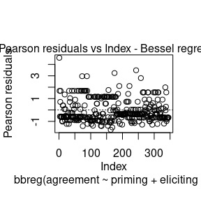

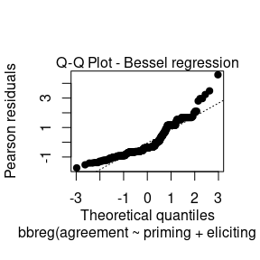

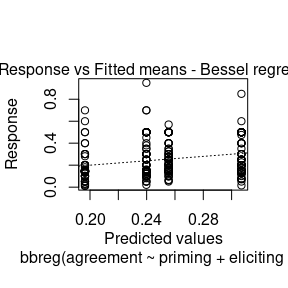

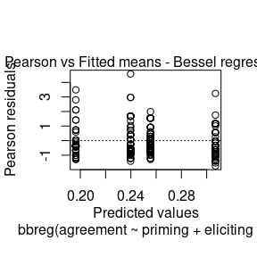

```r
plot(fit)
```

Notice that since there were no simulated envelopes for the **fit** object, the Q-Q plot does not contain simulated envelopes. Nevertheless, it contains a line connecting the first and third quartiles of the normal distribution (one can remove this line by setting the argument *qqline* to *FALSE*).

To choose a specific plot, one can set the parameter *which* to a vector containing the numbers of the plots to be shown. The plot numbers are given by: Plot 1: Residuals vs. Index; Plot 2: Q-Q Plot (if the fit contains simulated envelopes, the plot will be with the simulated envelopes); Plot 3: Fitted means vs. Response; Plot 4: Residuals vs. Fitted means.

For instance, if we only want to plot the Q-Q plot, we set the argument *which* to 2:

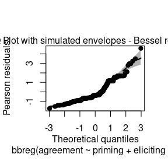

```r
plot(fit_envelope, which = 2)
```

Notice that since the **fit_envelope** object contains simulated envelopes, the Q-Q plot is displayed with simulated envelopes.

Finally, to avoid being asked between plots, just set the *ask* parameter to *FALSE*:

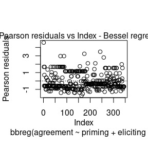

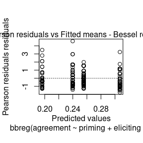

```r
plot(fit, which = c(1,4), ask = FALSE)
```